# Regresión

Daniel Felipe Pérez Grajales* *Universidad Nacional de Colombia - Sede Medellín* *Efraín Galvis Amaya* *Universidad Nacional de Colombia - Sede Medellín* **Profesor**: *Juan David Ospina Arango* *Universidad Nacional de Colombia - Sede Medellín* *Departamento de Ciencias de la Computación y de la Decisión* *Decisiones bajo incertidumbre (Optimización para aprendizaje de máquina)

28 de mayo de 2021

## Predicción del precio de la vivienda en Taiwan

Utilizando el conjunto de datos Real estate valuation data set Data Set lleve a un ejercicio del predicción del precio de la vivienda en Taiwan utilizando los siguientes métodos de predicción:

- Regresión lineal (clásica y elastic net)
- Ensambles de árboles: bosques aleatorios y XGBoost
- Máquinas de soporte vectorial
- Redes neuronales

Es posible dividir el conjunto de datos en entrenamiento y validación o uzar un esquema de validación cruzada.

El conjunto de datos se referncia en la siguiente cita: Citación: Yeh, I. C., & Hsu, T. K. (2018). Building real estate valuation models with comparative approach through case-based reasoning. Applied Soft Computing, 65, 260-271. La definición de las variables es la siguiente:

- X1: fecha de la transacción (por ejemplo 2013.250=2013 Marzo, * 2013.500=2013 Junio, etc.)
- X2: edad de la casa en años
- X3: distancial al MRT (transporte masivo) más cercano en metros
- X4: número de tiendas de conveniencia en el vecindario (entero)
- X5: latitud (unidad: grados)
- X6: longitude (unidad: grados)
- Y: precio por unidad de área (10000 Nuevos dólares taiwaneses/ 3.3 $m^2$)

### Data

|  | x1 | x2 | x3 | x4 | x5 | x6 | y |
| --- | --- | --- | --- | --- | --- | --- | --- |
| 1 | 2012.9166667 | 32 | 84.87882 | 10 | 24.98298 | 121.54024 | 37.9 |
| 2 | 2012.9166667 | 19.5 | 306.5947 | 9 | 24.98034 | 121.53951 | 42.2 |
| 3 | 2013.5833333 | 13.3 | 561.9845 | 5 | 24.98746 | 121.54391 | 47.3 |
| 4 | 2013.5 | 13.3 | 561.9845 | 5 | 24.98746 | 121.54391 | 54.8 |
| 5 | 2012.8333333 | 5 | 390.5684 | 5 | 24.97937 | 121.54245 | 43.1 |
| 6 | 2012.6666667 | 7.1 | 2175.03 | 3 | 24.96305 | 121.51254 | 32.1 |

### Descriptivo general

```
## [1] "Identificación de NA'S por variable"
```

```
## x1 x2 x3 x4 x5 x6  y
##  0  0  0  0  0  0  0
```

```
## [1] "Descriptivo de variables1"
```

```
##        x1             x2               x3                x4
##  Min.   :2013   Min.   : 0.000   Min.   :  23.38   Min.   : 0.000
##  1st Qu.:2013   1st Qu.: 9.025   1st Qu.: 289.32   1st Qu.: 1.000
##  Median :2013   Median :16.100   Median : 492.23   Median : 4.000
##  Mean   :2013   Mean   :17.713   Mean   :1083.89   Mean   : 4.094
##  3rd Qu.:2013   3rd Qu.:28.150   3rd Qu.:1454.28   3rd Qu.: 6.000
##  Max.   :2014   Max.   :43.800   Max.   :6488.02   Max.   :10.000
##        x5              x6              y
##  Min.   :24.93   Min.   :121.5   Min.   :  7.60
##  1st Qu.:24.96   1st Qu.:121.5   1st Qu.: 27.70
##  Median :24.97   Median :121.5   Median : 38.45
##  Mean   :24.97   Mean   :121.5   Mean   : 37.98
##  3rd Qu.:24.98   3rd Qu.:121.5   3rd Qu.: 46.60
##  Max.   :25.01   Max.   :121.6   Max.   :117.50
```

```
## [1] "Descriptivo de variables2"
```

```
## BD_REV
##
##  7  Variables      414  Observations
## --------------------------------------------------------------------------------
## x1
##        n  missing distinct     Info     Mean      Gmd      .05      .10
##      414        0       12    0.991     2013   0.3239     2013     2013
##      .25      .50      .75      .90      .95
##     2013     2013     2013     2014     2014
##
## lowest : 2012.667 2012.750 2012.833 2012.917 2013.000
## highest: 2013.250 2013.333 2013.417 2013.500 2013.583
##
## Value      2012.667 2012.750 2012.833 2012.917 2013.000 2013.083 2013.167
## Frequency        30       27       31       38       28       46       25
## Proportion    0.072    0.065    0.075    0.092    0.068    0.111    0.060
##
## Value      2013.250 2013.333 2013.417 2013.500 2013.583
## Frequency        32       29       58       47       23
## Proportion    0.077    0.070    0.140    0.114    0.056
## --------------------------------------------------------------------------------
## x2
##        n  missing distinct     Info     Mean      Gmd      .05      .10
##      414        0      236        1    17.71    12.93    1.100    3.500
##      .25      .50      .75      .90      .95
##    9.025   16.100   28.150   34.670   37.735
##
## lowest :  0.0  1.0  1.1  1.5  1.7, highest: 40.9 41.3 41.4 42.7 43.8
## --------------------------------------------------------------------------------
## x3
##        n  missing distinct     Info     Mean      Gmd      .05      .10
##      414        0      259        1     1084     1205    90.46   157.61
##      .25      .50      .75      .90      .95
##   289.32   492.23  1454.28  2697.66  4082.01
##
## lowest :   23.38284   49.66105   56.47425   57.58945   82.88643
## highest: 4605.74900 5512.03800 6306.15300 6396.28300 6488.02100
## --------------------------------------------------------------------------------
## x4
##        n  missing distinct     Info     Mean      Gmd      .05      .10
```

[output cut: 21 more lines]

```
##      414        0      232        1    121.5  0.01601    121.5    121.5
##      .25      .50      .75      .90      .95
##    121.5    121.5    121.5    121.5    121.5
##
## lowest : 121.4735 121.4752 121.4788 121.4846 121.4951
## highest: 121.5539 121.5548 121.5596 121.5617 121.5663
## --------------------------------------------------------------------------------
## y
##        n  missing distinct     Info     Mean      Gmd      .05      .10
##      414        0      270        1    37.98    15.13    16.49    21.02
##      .25      .50      .75      .90      .95
##    27.70    38.45    46.60    54.94    59.17
##
## lowest :   7.6  11.2  11.6  12.2  12.8, highest:  71.0  73.6  78.0  78.3 117.5
## --------------------------------------------------------------------------------
```

### Análisis de correlación de variables

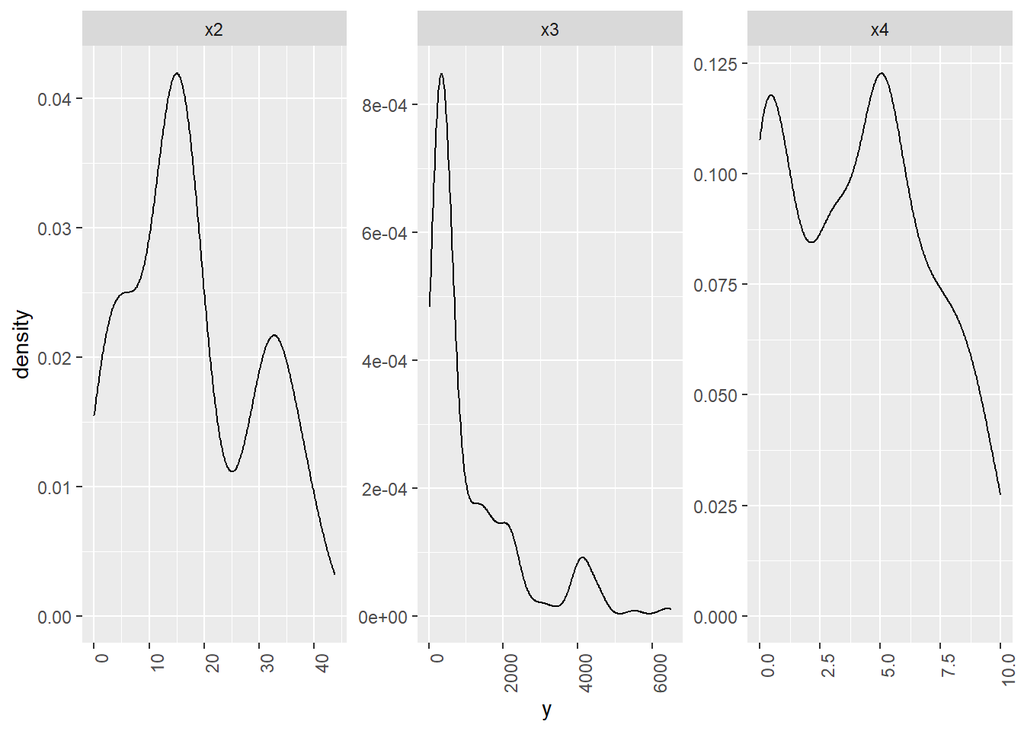

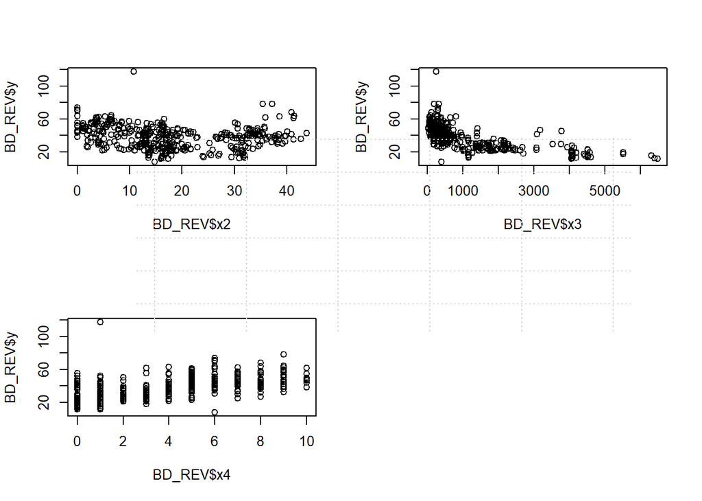

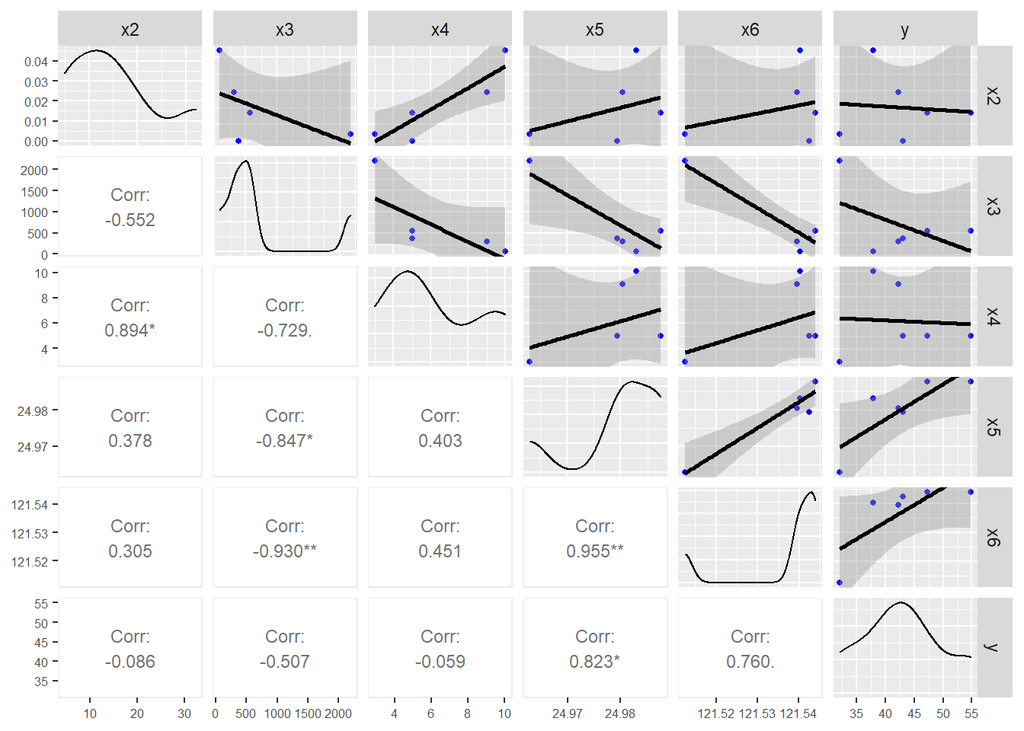

## se crean la variable año

```
##
## 2012 2013
##  126  288
```

# Modelamiento

escalamiento de las variables para transformarlas

|  | x2 | x3 | x4 | x5 | x6 | y | ano |
| --- | --- | --- | --- | --- | --- | --- | --- |
| 1 | 1.25411095111314 | -0.791537337603565 | 2.00498155906755 | 1.12406982714272 | 0.448219913805753 | -0.00589374998871483 | -1.51003087276874 |
| 2 | 0.156896382725905 | -0.615866476050253 | 1.66548774906593 | 0.911341529024461 | 0.400654181399245 | 0.310131964767615 | -1.51003087276874 |
| 3 | -0.387322043194166 | -0.413514952118236 | 0.307512509059441 | 1.4850633027372 | 0.687351746592361 | 0.684953161339074 | 0.660638506836446 |
| 4 | -0.387322043194166 | -0.413514952118236 | 0.307512509059441 | 1.4850633027372 | 0.687351746592361 | 1.23616080335593 | 0.660638506836446 |
| 5 | -1.11587251660329 | -0.549332079746211 | 0.307512509059441 | 0.833179995245957 | 0.59222028177842 | 0.376276881809637 | -1.51003087276874 |
| 6 | -0.931540469114237 | 0.864540064553073 | -0.371475110943804 | -0.481867665849 | -1.35667157616393 | -0.432160993148414 | -1.51003087276874 |

### Regresión lineal (clásica)

```
## Start:  AIC=-347.13
## y ~ x2 + x3 + x4 + x5 + x6 + ano
##
##        Df Sum of Sq    RSS     AIC
## - x6    1    0.0422 173.09 -349.03
## <none>              173.05 -347.13
## - ano   1    4.0622 177.11 -339.52
## - x5    1   11.8053 184.85 -321.81
## - x3    1   15.8054 188.85 -312.95
## - x4    1   16.1937 189.24 -312.10
## - x2    1   21.4938 194.54 -300.66
##
## Step:  AIC=-349.03
## y ~ x2 + x3 + x4 + x5 + ano
##
##        Df Sum of Sq    RSS     AIC
## <none>              173.09 -349.03
## + x6    1    0.0422 173.05 -347.13
## - ano   1    4.0309 177.12 -341.50
## - x5    1   12.1621 185.25 -322.92
## - x4    1   16.3458 189.44 -313.67
## - x2    1   21.4538 194.54 -302.66
## - x3    1   31.5232 204.61 -281.76
```

```
##
## Call:
## lm(formula = y ~ x2 + x3 + x4 + x5 + ano, data = BD_REV)
##
## Coefficients:
## (Intercept)           x2           x3           x4           x5          ano
##  -3.768e-14   -2.297e-01   -3.900e-01    2.523e-01    2.154e-01    9.894e-02
```

```
##
## Call:
## lm(formula = y ~ x2 + x3 + x4 + x5 + ano, data = BD_REV)
##
## Residuals:
##     Min      1Q  Median      3Q     Max
## -2.6066 -0.3877 -0.0792  0.3060  5.5509
##
## Coefficients:
##               Estimate Std. Error t value Pr(>|t|)
## (Intercept) -3.768e-14  3.201e-02   0.000  1.00000
## x2          -2.297e-01  3.230e-02  -7.111 5.19e-12 ***
## x3          -3.900e-01  4.525e-02  -8.620  < 2e-16 ***
## x4           2.523e-01  4.064e-02   6.207 1.33e-09 ***
## x5           2.154e-01  4.023e-02   5.354 1.44e-07 ***
## ano          9.894e-02  3.210e-02   3.082  0.00219 **
## ---
## Signif. codes:  0 '***' 0.001 '**' 0.01 '*' 0.05 '.' 0.1 ' ' 1
##
## Residual standard error: 0.6513 on 408 degrees of freedom
## Multiple R-squared:  0.5809, Adjusted R-squared:  0.5758
## F-statistic: 113.1 on 5 and 408 DF,  p-value: < 2.2e-16
```

```
## [1] "la variable mas significativa es:  x3"
```

Calculando RMSE para la regresión

el modelo de regresión Lineal tiene un error cuadrático medio de:

```
## [1] "64.66%"
```

es decir, el modelo es capaz de predecir con una precisión del

```
## [1] "35.34%"
```

el precio por unidad de área de la vivienda en Taiwan.

### Regresión lineal (elastic net)

Mejor parámetros del modelo

```
##       alpha    lambda
## 1 0.1179111 0.0147797
```

el modelo de regresión elastic net tiene error cuadrático medio de

```
## [1] "68.89%"
```

es decir, el modelo es capaz de predecir con una precisión del

```
## [1] "31.11%"
```

el precio por unidad de área de la vivienda en Taiwan.

### Ensambles de árboles

bosques aleatorios

```
##
## Call:
##  randomForest(formula = y ~ ., data = train, mtry = 3, importance = TRUE,      ntrees = 500)
##                Type of random forest: regression
##                      Number of trees: 500
## No. of variables tried at each split: 3
##
##           Mean of squared residuals: 0.3104596
##                     % Var explained: 68.92
```

```
##       %IncMSE
## x2  22.689480
## x3  33.852053
## x4  10.986734
## x5  27.888706
## x6  18.525058
## ano  4.188503
```

se concluye que: la variable mas importante es X3:distancia al MRT (transporte masivo) más cercano en metros seguido de la X5: Latitud, es decir posición de la ubicación del inmueble suceptible al norte o sur de taiwan para predecir el precio por unidad de área de la vivienda en Taiwan.

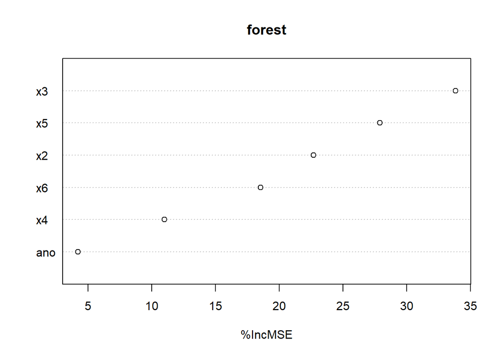

el modelo de bosques aleatorios tiene un error cuadrático medio de

```
## [1] "48.43%"
```

es decir, el modelo es capaz de predecir con una precisión del

```
## [1] "51.57%"
```

el precio por unidad de área de la vivienda en Taiwan.

### XGBoost

```
## ##### xgb.Booster
## raw: 39.1 Kb
## call:
##   xgb.train(params = params, data = dtrain, nrounds = nrounds,
##     watchlist = watchlist, verbose = verbose, print_every_n = print_every_n,
##     early_stopping_rounds = early_stopping_rounds, maximize = maximize,
##     save_period = save_period, save_name = save_name, xgb_model = xgb_model,
##     callbacks = callbacks, max.depth = 2)
## params (as set within xgb.train):
##   max_depth = "2", validate_parameters = "1"
## xgb.attributes:
##   niter
## callbacks:
##   cb.print.evaluation(period = print_every_n)
##   cb.evaluation.log()
## # of features: 6
## niter: 50
## nfeatures : 6
## evaluation_log:
##     iter train_rmse
##        1   0.894282
##        2   0.752198
## ---
##       49   0.353553
##       50   0.350771
```

```
## MSE:  0.3020466 MAE:  0.3971128  RMSE:  0.5495877
```

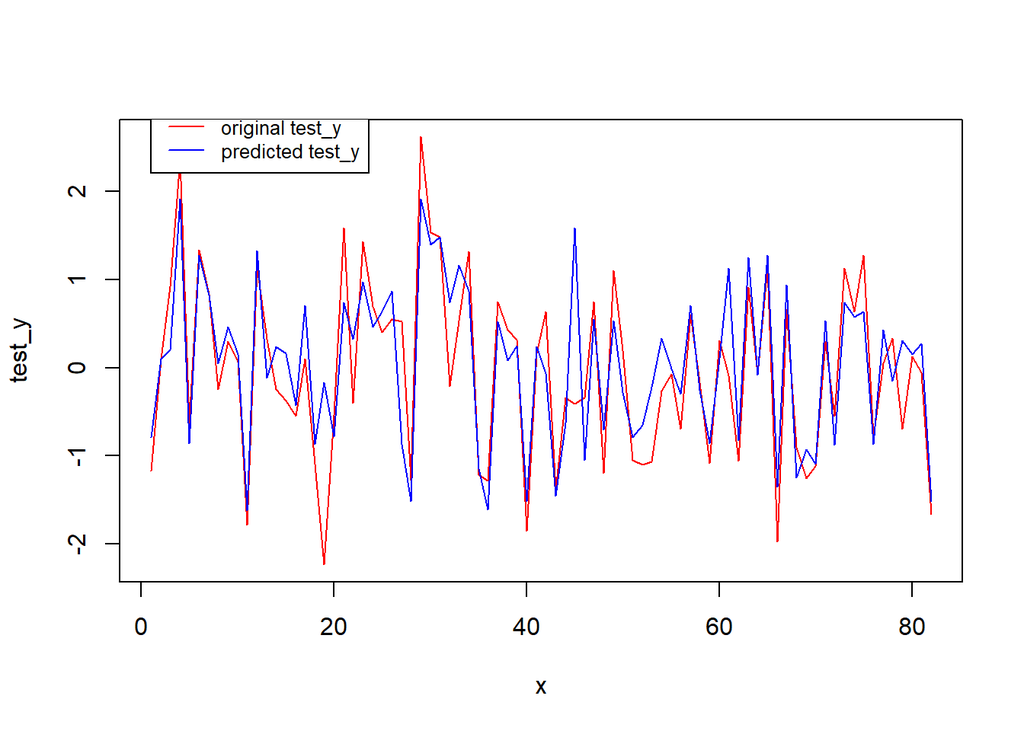

el modelo XGBoost tiene error cuadrático medio de

```
## [1] "54.96%"
```

es decir, el modelo es capaz de predecir con una precisión del

```
## [1] "45.04%"
```

el precio por unidad de área de la vivienda en Taiwan.

### Máquinas de soporte vectorial

el modelo de máquinas de soporte vectorial tiene error cuadrático medio de

```
## [1] "48.87%"
```

es decir, el modelo es capaz de predecir con una precisión del

```
## [1] "51.13%"
```

el precio por unidad de área de la vivienda en Taiwan.

### Redes neuronales

el modelo de Redes neuronales tiene error cuadrático medio de

```
## [1] "60.47%"
```

es decir, el modelo es capaz de predecir con una precisión del

```
## [1] "39.53%"
```

el precio por unidad de área de la vivienda en Taiwan.

## Preguntas adicionales

*1. ¿Qué variables tienen el mayor impacto en el precio de la vivienda?*

Las variables X3:distancia al MRT (transporte masivo) más cercano en metros en el análisis de correlación se evidencia una dependecia lineal medianamente al precio por unidad de área de la vivienda en Taiwan.

*¿Cómo aporta cada modelo al conocimiento de este impacto?*

En el ajuste de los modelos, para la regresión lineal es la variable más significativa es X3:distancia al MRT (transporte masivo) más cercano en metros, al igual que el modelo bosques aleatorios, adicionalmente este modelo considera que la posición del inmueble en sentido sur o norte x5: Lat,es influyente en el precio por unidad de área de la vivienda en Taiwan.

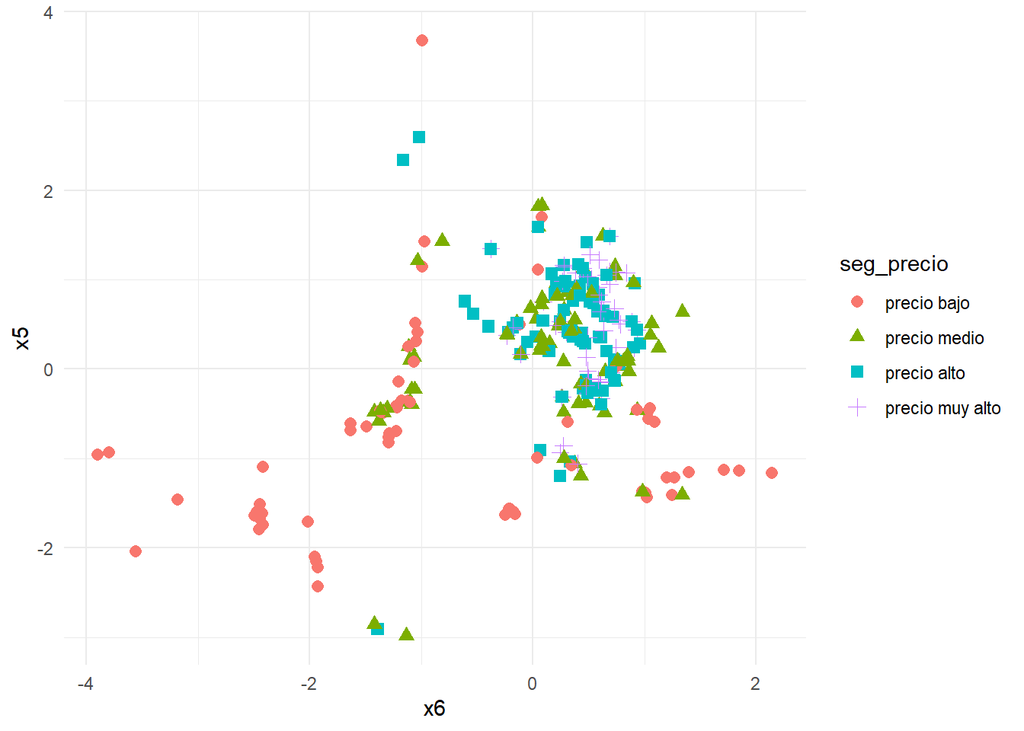

*2. ¿Cuál es el mejor modelo entre los usados para resolver este problema?*

El modelo de bosques aleatorios que tiene un error cuadrático medio de

```
## [1] "48.43%"
```

es decir, es capaz de predecir con una precisión del

```
## [1] "51.57%"
```

el precio por unidad de área de la vivienda en Taiwan y fue el modelo con el mejor ajuste.

*¿Qué criterios se pueden utilizar para responder a esta pregunta?*

para este caso por los modelos de: Regresión lineal (clásica y elastic net),Ensambles de árboles: bosques aleatorios y XGBoost,Máquinas de soporte vectorial, Redes neuronales, se busca una medida del error de ajuste de la predicción que se pueda calcular en todos los modelos como lo es el error cuadrático medio(RMSE) y se pueda comparar entre todos.El de menor RMSE será el que tiene mejor ajuste al predecir el precio por unidad de área de la vivienda en Taiwan.

```
##     rmse_ml rmse_elastic forest_rmse    rmseXG   RMSEsvm  nnetrsme
## 1 0.6466006    0.6888986   0.4842759 0.5495877 0.4886861 0.6047148
```

por lo que el modelo de bosques aleatorios que tiene un error cuadrático medio más bajo de

```
## [1] "48.43%"
```

es decir, es capaz de predecir con una precisión del

```
## [1] "51.57%"
```

el precio por unidad de área de la vivienda en Taiwan.